# Interactive Code Lecture 3

POLISCI 251A Introduction to Machine Learning

7/2/2018

## 1. Relating variables

### 1.1

In this session we are going to introduce two new functions used to generate random numbers. -‘set.seed()’ uses a single integer argument to set a seed in your computer that will allow you to replicate a random number generator. -The second function is an example of random number generator from an specific distribution, in this case, the Normal distribution. In this chunk you are going to create two vectors of 100 numbers from a Normal distribution with mean 0 and standard deviation 1. *Hint: Again, always looking to the help window first is always advisable*

```r
# First, let's set the seed to 124
# YOUR CODE HERE
set.seed(124)
# Create my_x using rnorm()
# YOUR CODE HERE
my_x <- rnorm(100, mean=0, sd=1)
# Create my_y
# YOUR CODE HERE
my_y <- rnorm(100 ,mean=0, sd=1)
```

Take a look to the distribution of these numbers by creating a histogram of ‘my_’x using the function ’hist()’.

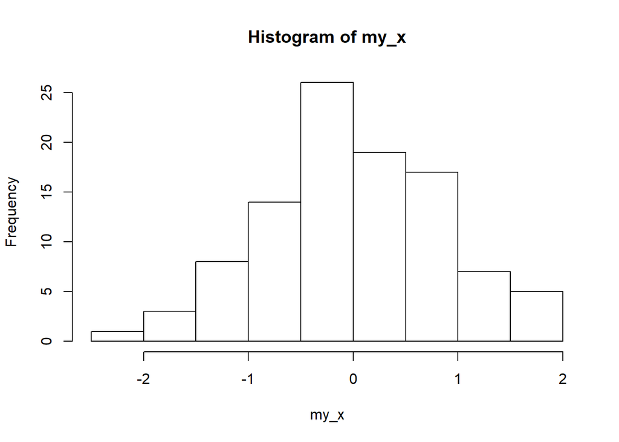

```r
# YOUR CODE HERE
hist(my_x, breaks = 10)
```

Now, let’s plot ‘my_x’ against ‘my_y’ using the function ‘plot()’. In this occasion we also are going to include some additional arguments to make a nicer plot. In particular, let’s specify ‘pch=20’ to modify the default points and name the axis as ‘X’ and ‘Y’. Take a look to the help window for this function first.

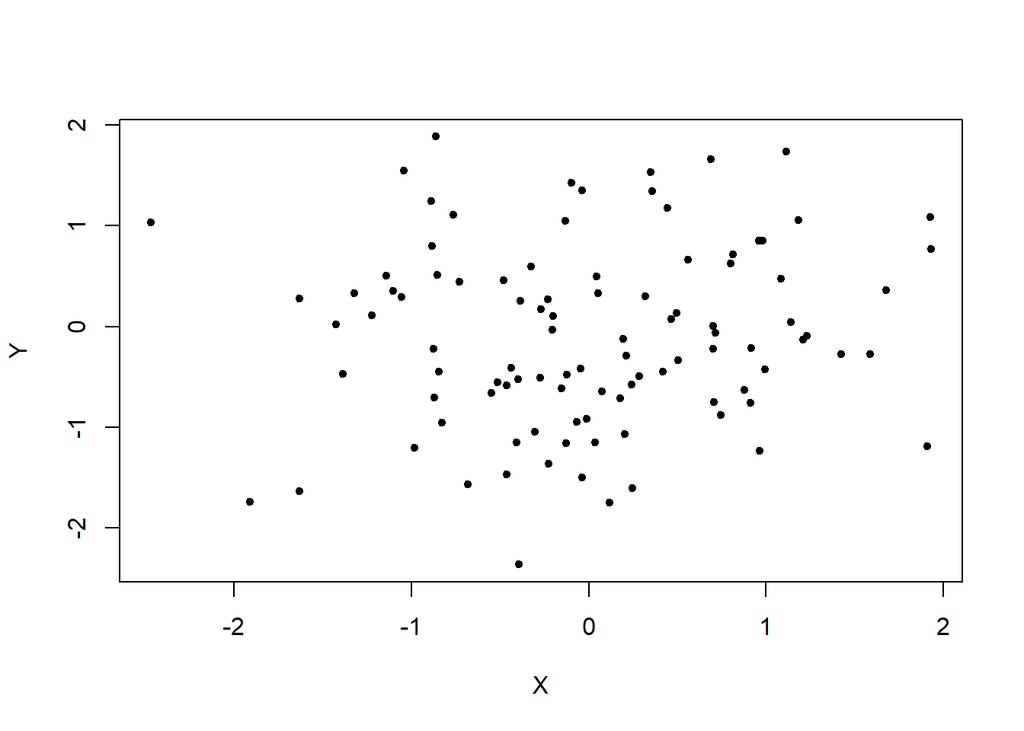

```r
# YOUR CODE HERE
plot(my_x, my_y,pch = 20, xlab= 'X', ylab = 'Y')
```

### 1.2 Correlation

To measure the dependence between variables there are several measures, the most common is the Pearson product-moment correlation coefficient.

$$\rho_{X,Y}=Corr(X,Y)=\dfrac{Cov(X,Y)}{\sigma_X \sigma_Y} = \dfrac{E[(X-\mu_X)(Y -\mu_Y)]}{\sigma_X \sigma_Y}$$
where E is the expected value operator, *cov* means covariance, $\sigma$ are the standard deviations, $\mu$ the mean expected values for each variable, and *corr* is a widely used alternative notation for the correlation coefficient.

This value goes from -1 to 1. The Pearson correlation is 1 in the case of a perfect direct (increasing) linear relationship (correlation), −1 in the case of a perfect decreasing (inverse) linear relationship. If the correlation coefficient is 0 then we say that the two variables are independent.

Using the function ‘cor()’ calculate the correlation between your variables.

```r
# YOUR CODE HERE
cor(my_x, my_y)
```

```
## [1] 0.09439334
```

We can see that the correlation is quite low. This is not surprising since we created these two variables independently.

### 1.3 Creating Correlated Variables

The next step is to create two variables that are not independent. To do so, we are going to use a correlation of 0.7. Follow the code to create two correlated variables.

```r
# First install the MASS package and get the library
#install.packages("MASS")
library(MASS)

# We will use the command mvrnorm to draw a matrix of variables

# Let's keep it simple,
mu <- rep(0,2) ## Mean 0 for both variables
Sigma <- matrix(.7, nrow=2, ncol=2) + diag(2)*.3 ## Correlation matrix

set.seed(124)
rawvars <- mvrnorm(n=100, mu=mu, Sigma=Sigma)
```

Take a look to the correlation between these variables:

```r
# YOUR CODE HERE
cor(rawvars)
```

```
##           [,1]      [,2]
## [1,] 1.0000000 0.6893955
## [2,] 0.6893955 1.0000000
```

Wait! The correlation is not exactly 0.7. Why this might be happening?

**Answer:** These variables were sampled from a multivariate normal distribution, so they only represent a larger population. We should expect that a larger sample would represent the population better and thus show a correlation closer to 0.7.

Now, plot your two variables

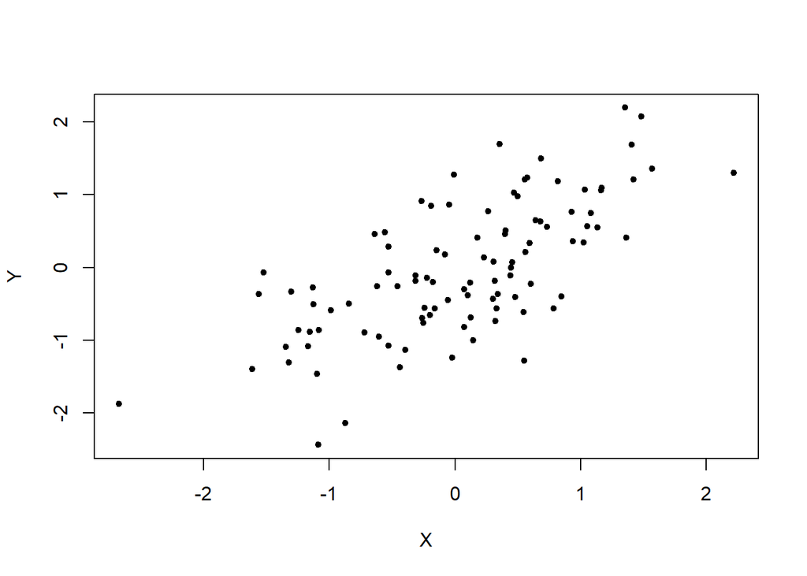

```r
# YOUR CODE HERE
plot(rawvars,pch = 20, xlab= 'X', ylab = 'Y')
```

**STOP!**

## 2. Setting up the time for a change model

The time-for-change model, developed by Alan Abramowitz, predicts the two-party popular vote based on the state of the economy, the incumbent’s popularity, and the time the incumbent president has been in office.

### 2.1

Download and create in object from the .csv file ``TimeChange.csv" into your computer. What class is the object you just created?

```r
# set your working directory
# YOUR CODE HERE
setwd('C://Users/Edgar/Dropbox/PhD/5_year/summer/ML_class/Lectures/Lecture3')
# Create an object called 'elect' using the read.csv function
# YOUR CODE HERE
elect<- read.csv('TimeChange.csv')
# Use the function class()
# YOUR CODE HERE
class(elect)
```

```
## [1] "data.frame"
```

### 2.2

Print the dimensions of the matrix and the column names using the ‘dim()’ function and the ‘colnames()’ function.

```r
# YOUR CODE HERE
dim(elect)
```

```
## [1] 17  6
```

```r
colnames(elect)
```

```
## [1] "Year"                      "Q1_GDP_Growth"
## [3] "Q2_GDP_Growth"             "Incumbent_Net_Approval"
## [5] "Incumbent_Party_Two_Terms" "IncumbentVoteShare"
```

### 2.3

Provide Summary Statistics for each variable in the data set.

```r
# YOUR CODE HERE
summary(elect)
```

```
##       Year      Q1_GDP_Growth    Q2_GDP_Growth    Incumbent_Net_Approval
##  Min.   :1948   Min.   :-1.800   Min.   :-7.900   Min.   :-37.000
##  1st Qu.:1964   1st Qu.: 2.000   1st Qu.: 1.300   1st Qu.: -6.000
##  Median :1980   Median : 4.100   Median : 4.300   Median :  5.000
##  Mean   :1980   Mean   : 4.429   Mean   : 3.688   Mean   :  7.694
##  3rd Qu.:1996   3rd Qu.: 8.000   3rd Qu.: 7.100   3rd Qu.: 20.000
##  Max.   :2012   Max.   : 9.400   Max.   : 9.800   Max.   : 60.300
##  Incumbent_Party_Two_Terms IncumbentVoteShare
##  Min.   :0.0000            Min.   :44.50
##  1st Qu.:0.0000            1st Qu.:48.90
##  Median :1.0000            Median :51.10
##  Mean   :0.5294            Mean   :52.01
##  3rd Qu.:1.0000            3rd Qu.:54.70
##  Max.   :1.0000            Max.   :61.80
```

**STOP!**

## 3. Simple Regression

### 3.1

Our first endeavor will be to predict IncumbentVoteShare with Incumbent_Net_Approval.

Create a plot of IncumbentVoteShare against Incumbent_Net_Approval.

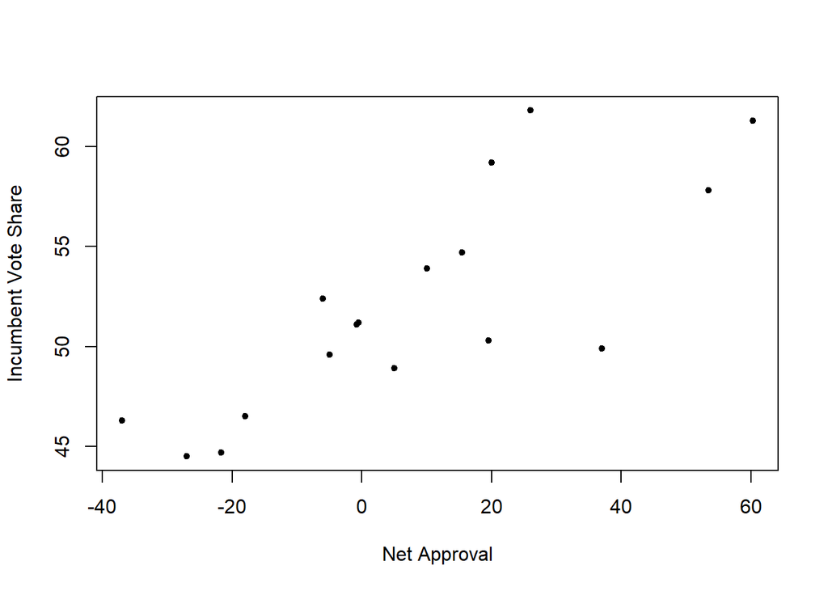

```r
# YOUR CODE HERE
plot(elect$IncumbentVoteShare ~ elect$Incumbent_Net_Approval, pch = 20, xlab = 'Net Approval', ylab = 'Incumbent Vote Share')
```

### 3.2

Create an object called ‘mod’ that contains the regression of `IncumbentVoteShare` against `Incumbent_Net_Approval`. The function to create a linear regression works as follows: lm(y~x, data=‘your_dataset’). Here, ‘y’ stands for the variable we want to predict (dependent variable) and ‘x’ for the predictor(s). This function produces the coefficients for the linear model.

```r
## YOUR CODE HERE
mod <- lm(IncumbentVoteShare ~ Incumbent_Net_Approval, data = elect)
## Now, use the function summarize to observe the results
summary(mod)
```

```
##
## Call:
## lm(formula = IncumbentVoteShare ~ Incumbent_Net_Approval, data = elect)
##
## Residuals:
##     Min      1Q  Median      3Q     Max
## -6.8532 -1.8857  0.4701  1.5206  6.8287
##
## Coefficients:
##                        Estimate Std. Error t value Pr(>|t|)
## (Intercept)            50.75949    0.85129   59.63  < 2e-16 ***
## Incumbent_Net_Approval  0.16199    0.03122    5.19  0.00011 ***
## ---
## Signif. codes:  0 '***' 0.001 '**' 0.01 '*' 0.05 '.' 0.1 ' ' 1
##
## Residual standard error: 3.367 on 15 degrees of freedom
## Multiple R-squared:  0.6423, Adjusted R-squared:  0.6184
## F-statistic: 26.93 on 1 and 15 DF,  p-value: 0.0001099
```

### 3.3

Include a regression line of `IncumbentVoteShare` against `Incumbent_Net_Approval` on the plot. *Hint: abline might be useful*

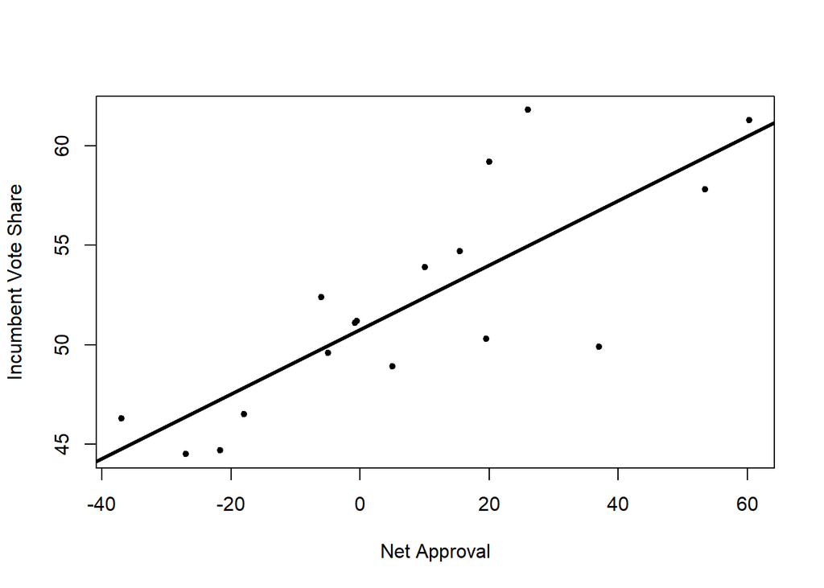

```r
## YOUR CODE HERE
plot(elect$IncumbentVoteShare ~ elect$Incumbent_Net_Approval, pch = 20, xlab = 'Net Approval', ylab = 'Incumbent Vote Share')
abline(mod, lwd = 3)
```

### 3.4

Now, using the regression object you used to add the line to your plot, check the names that are provided in the `lm` object. Summarize:

1. Fitted Values
2. Residuals

And store the coefficients in a vector.

```r
## YOUR CODE HERE
names(mod)
```

```
##  [1] "coefficients"  "residuals"     "effects"       "rank"
##  [5] "fitted.values" "assign"        "qr"            "df.residual"
##  [9] "xlevels"       "call"          "terms"         "model"
```

```r
summary(mod$fitted.values)
```

```
##    Min. 1st Qu.  Median    Mean 3rd Qu.    Max.
##   44.77   49.79   51.57   52.01   54.00   60.53
```

```r
summary(mod$residuals)
```

```
##    Min. 1st Qu.  Median    Mean 3rd Qu.    Max.
## -6.8532 -1.8857  0.4701  0.0000  1.5206  6.8287
```

```r
coef <- mod$coefficients
```

**STOP!**

## 4. Prediction

### 4.1

`predict` is an extremely useful function that you’ve likely worked with before. Today, we’re going to write our own function using an `lm` object.

Implement a prediction function that takes as an argument an lm object and a value for net approval.

```r
## YOUR CODE HERE
lm_pred<- function(obj, indep){
  coefs<- obj$coefficients
  pred<- coefs[1] + coefs[2]*indep
  return(pred)
}
```

### 3.2

Report the prediction for the following values: -4, 100, -100, 50

```r
## YOUR CODE HERE
lm_pred(mod, c(-4, 100, -100, 50))
```

```
## [1] 50.11152 66.95880 34.56018 58.85914
```